# 2021-03-16

M Schaefer

19/06/2021

# 1 Load libraries

```r
# library(tidytuesdayR) # only to initially download data
library(tidyverse)
library(ggdark) # for dark minimal theme
```

# 2 Download and save data

```r
# tuesdata <- tidytuesdayR::tt_load('2021-03-16')
#
# dat <- tuesdata$games
#
# write_csv(dat, "data.csv")

dat <- read_csv("data.csv")
```

# 3 Check out the data

```r
View(dat)
skimr::skim(dat)
```

Data summary

| Name | dat |
| --- | --- |
| Number of rows | 83631 |
| Number of columns | 7 |
| _______________________ |  |
| Column type frequency: |  |
| character | 3 |
| numeric | 4 |
| ________________________ |  |
| Group variables | None |

**Variable type: character**

| skim_variable | n_missing | complete_rate | min | max | empty | n_unique | whitespace |
| --- | --- | --- | --- | --- | --- | --- | --- |
| gamename | 0 | 1 | 3 | 81 | 0 | 1258 | 0 |
| month | 0 | 1 | 3 | 9 | 0 | 12 | 0 |
| avg_peak_perc | 0 | 1 | 2 | 8 | 0 | 71354 | 0 |

**Variable type: numeric**

| skim_variable | n_missing | complete_rate | mean | sd | p0 | p25 | p50 | p75 | p100 | hist |
| --- | --- | --- | --- | --- | --- | --- | --- | --- | --- | --- |
| year | 0 | 1.00 | 2017.34 | 2.24 | 2012 | 2016.00 | 2018.00 | 2019.00 | 2021.0 | ▂▅▆▇▅ |
| avg | 0 | 1.00 | 2765.73 | 26500.54 | 0 | 53.11 | 203.07 | 763.97 | 1584886.8 | ▇▁▁▁▁ |
| gain | 1258 | 0.98 | -10.29 | 3790.65 | -250249 | -38.18 | -1.62 | 22.24 | 426446.1 | ▁▇▁▁▁ |
| peak | 0 | 1.00 | 5469.95 | 50184.65 | 0 | 137.00 | 500.00 | 1727.00 | 3236027.0 | ▇▁▁▁▁ |

What I notice:

- 1258 unique games `gamename`; need to convert to a factor
- years range from 2012 - 2021 `year`; need to convert to a factor
- `month` needs to be converted to a factor
- from data dictionary
  - `avg` = average number of players at the same time
  - `peak` = most players at same time

# 4 Convert some variables to factors

```r
dat <- dat %>% mutate(across(c(gamename, year), as_factor))
```

# 5 Compare average number of players per month and year over time for Dota 2

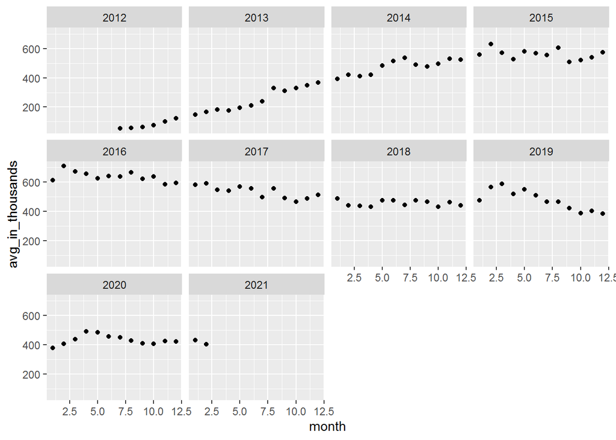

```r
dat %>% filter(gamename == "Dota 2") %>%      # keep only Dota 2
  mutate(avg_in_thousands = round((avg/1000), 0 )) %>% # reduce numbers on the graph by dividing by 1000
  mutate(month = case_when(   # covert months to numbers so that the months are lsited correctly in the graph
    month == "January" ~ 1,
    month == "February" ~ 2,
    month == "March" ~ 3,
    month == "April" ~ 4,
    month == "May" ~ 5,
    month == "June" ~ 6,
    month == "July" ~ 7,
    month == "August" ~ 8,
    month == "September" ~ 9,
    month == "October" ~ 10,
    month == "November" ~ 11,
    month == "December" ~ 12
  )) %>% mutate(month = as.numeric(month)) %>%
  ggplot(aes(x = month, y = avg_in_thousands)) +
  geom_point() + facet_wrap(~year)
```

```r
ggsave("avg-change-over-time.png")
```

# 6 Compare peak number of players per month and year over time for Dota 2

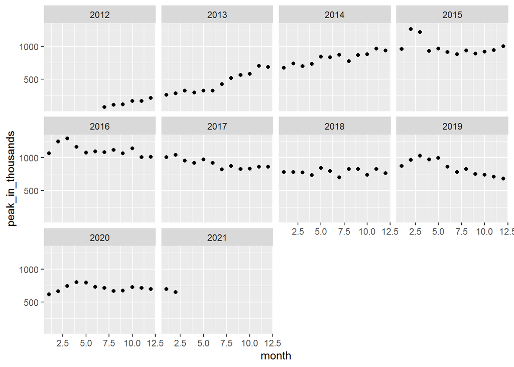

```r
dat %>% filter(gamename == "Dota 2") %>%      # keep only Dota 2
  mutate(peak_in_thousands = round((peak/1000), 0 )) %>% # reduce numbers on the graph by dividing by 1000
  mutate(month = case_when(   # covert months to numbers so that the months are lsited correctly in the graph
    month == "January" ~ 1,
    month == "February" ~ 2,
    month == "March" ~ 3,
    month == "April" ~ 4,
    month == "May" ~ 5,
    month == "June" ~ 6,
    month == "July" ~ 7,
    month == "August" ~ 8,
    month == "September" ~ 9,
    month == "October" ~ 10,
    month == "November" ~ 11,
    month == "December" ~ 12
  )) %>% mutate(month = as.numeric(month)) %>%
  ggplot(aes(x = month, y = peak_in_thousands)) +
  geom_point() + facet_wrap(~year)
```

```r
ggsave("peak-change-over-time.png")
```

# 7 In a given year, are the peaks affected by Dota 2 related events such as The International?

First plot the peak values per month for 2019. I chose 2019 since this was the last ‘normal’ year we had, and I rememebr my husband, Mark, playing Dota 2 that year.

## 7.1 Save data in a new object to make graph generation faster

```r
dat_graph <-  dat %>%
  filter(gamename == "Dota 2", # keep only Dota 2
         year == 2019) %>%     # keep only year 2019
  mutate(peak_in_thousands = round((peak/1000), 0 )) %>% # reduce numbers on the graph by dividing by 1000
  mutate(month = case_when(   # convert months to numbers so that the months are listed in order in the graph
    month == "January" ~ 1,
    month == "February" ~ 2,
    month == "March" ~ 3,
    month == "April" ~ 4,
    month == "May" ~ 5,
    month == "June" ~ 6,
    month == "July" ~ 7,
    month == "August" ~ 8,
    month == "September" ~ 9,
    month == "October" ~ 10,
    month == "November" ~ 11,
    month == "December" ~ 12
  )) %>% mutate(month = as.numeric(month))  # convert to numeric so that the months will be listed in order
```

## 7.2 Make reasonable base graph

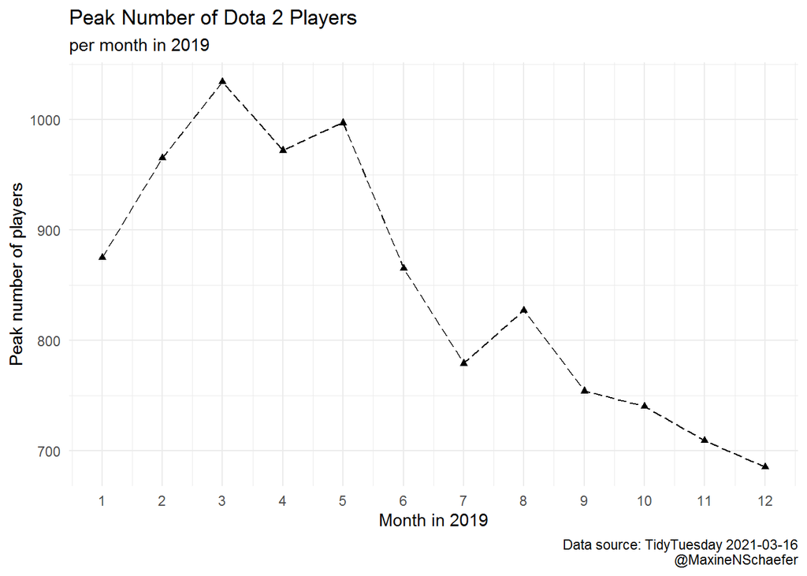

```r
p1 <- dat_graph %>% ggplot(aes(x = month, y = peak_in_thousands)) +
  geom_point(shape = 17) + # add points
  geom_line(linetype = 5) + # add lines to join points
  theme_minimal() +  # add a minimal theme
  labs(x = "Month in 2019",  # add labels
       y = "Peak number of players",
       title = "Peak Number of Dota 2 Players",
       subtitle = "per month in 2019",
       caption = "Data source: TidyTuesday 2021-03-16
       @MaxineNSchaefer") +
  scale_x_continuous(n.breaks = 12)  # have a break for each month

p1
```

```r
ggsave("p1.png")
```

## 7.3 Add data for International 2019

The International in 2019 began on 7 July and the final was on 26 August. Add these dates using `vline()`.

```r
TIstart <- (7/30) + 7
TIend <- (26/30) + 8
```

Add TI start and end to graph.

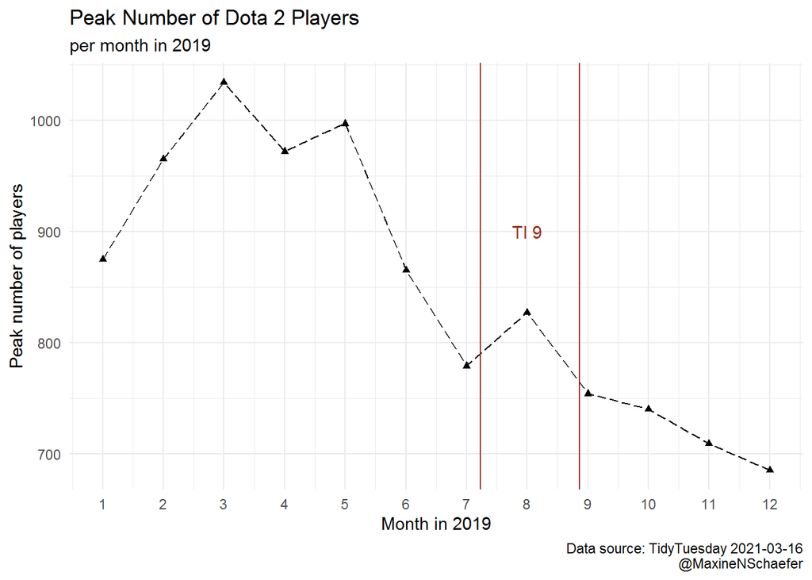

```r
p1 +
  geom_vline(xintercept = TIstart, color = "#982f1f") + # add start date and color using Dota 2 colour
  geom_vline(xintercept = TIend, color = "#982f1f") + # add end date and color using Dota 2 colour
  annotate(geom="text", x=8, y=900, label="TI 9",
              color="#982f1f")
```

# 8 Make a prettier vis

Dota 2 as a game is quite dark. Redo the graph with a dark background and light elements.

## 8.1 New base graph

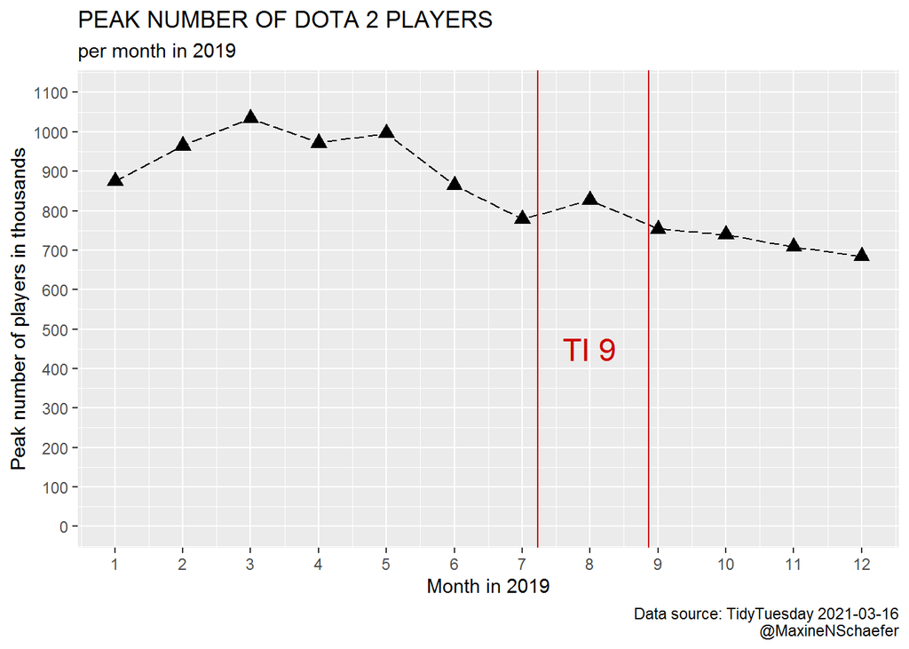

```r
# data to work with
dat_graph <-  dat %>%
  filter(gamename == "Dota 2", # keep only Dota 2
         year == 2019) %>%     # keep only year 2019
  mutate(peak_in_thousands = round((peak/1000), 0 )) %>% # reduce numbers on the graph by dividing by 1000
  mutate(month = case_when(   # convert months to numbers so that the months are listed in order in the graph
    month == "January" ~ 1,
    month == "February" ~ 2,
    month == "March" ~ 3,
    month == "April" ~ 4,
    month == "May" ~ 5,
    month == "June" ~ 6,
    month == "July" ~ 7,
    month == "August" ~ 8,
    month == "September" ~ 9,
    month == "October" ~ 10,
    month == "November" ~ 11,
    month == "December" ~ 12
  )) %>% mutate(month = as.numeric(month))  # convert to numeric so that the months will be listed in order

# TI start and end
TIstart <- (7/30) + 7
TIend <- (26/30) + 8

# base graph
p2 <- dat_graph %>% ggplot(aes(x = month, y = peak_in_thousands)) +
  geom_point(shape = 17, size = 3) + # add points
  geom_line(linetype = 5) + # add lines to join points
  labs(x = "Month in 2019",  # add labels
       y = "Peak number of players in thousands",
       title = "PEAK NUMBER OF DOTA 2 PLAYERS",
       subtitle = "per month in 2019",
       caption = "Data source: TidyTuesday 2021-03-16
       @MaxineNSchaefer") +
  scale_x_continuous(n.breaks = 12) + # have a break for each month
  scale_y_continuous(limits = c(0, 1100), breaks = c(0, 100, 200, 300, 400, 500, 600, 700, 800, 900, 1000, 1100)) +
  geom_vline(xintercept = TIstart, color = "#cc0000") + # add start date and color using Dota 2 colour
  geom_vline(xintercept = TIend, color = "#cc0000") + # add end date and color using Dota 2 colour
  annotate(geom="text", x=8, y=450, label="TI 9", color="#cc0000", size = 6) # add text to graph

p2
```

```r
ggsave("p2.png")
```

## 8.2 Make graph darker

```r
p3 <- p2 + dark_theme_minimal() + # add basic dark theme

  # edit theme to match Dota 2 colours more or less
  theme(axis.title = element_text(colour = "#b22222", face = "bold"),
        plot.title = element_text(size = 20, colour = "#cc0000", face = "bold", family = "serif"),
        plot.subtitle = element_text(colour = "#cc0000"),
        plot.caption = element_text(colour = "#b22222"),
        axis.text = element_text(colour = "#b22222"),
        panel.grid.major = element_blank(), # remove grid lines
        panel.grid.minor = element_blank()) +  # remove grid lines

  annotate(geom="text", x=10, y=450, label= # add text to indicate prize pool value
  "Prize pool
  34.33 mil USD", color="#cc0000", size = 4)
```

```
## Inverted geom defaults of fill and color/colour.
## To change them back, use invert_geom_defaults().
```

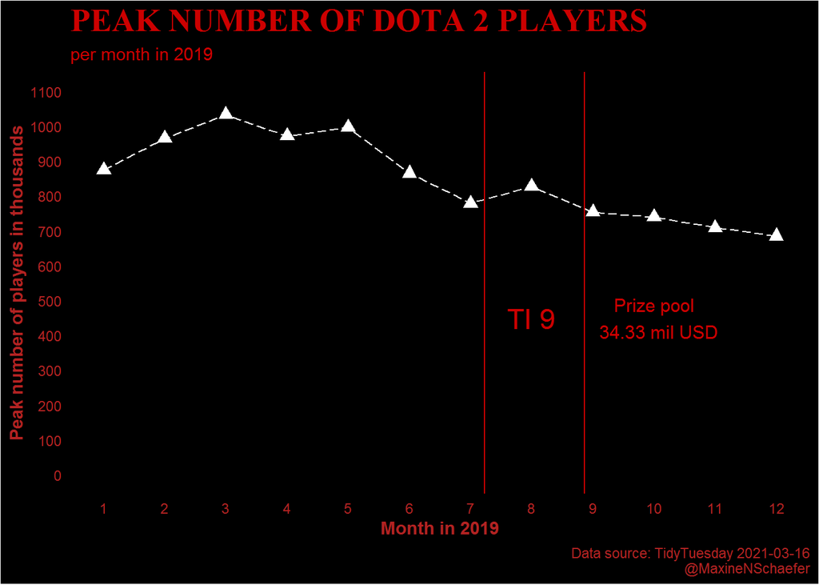

```r
p3
```

# 9 Save the output

```r
ggsave("dotaplot.png")
```

# 10 All the code in one place

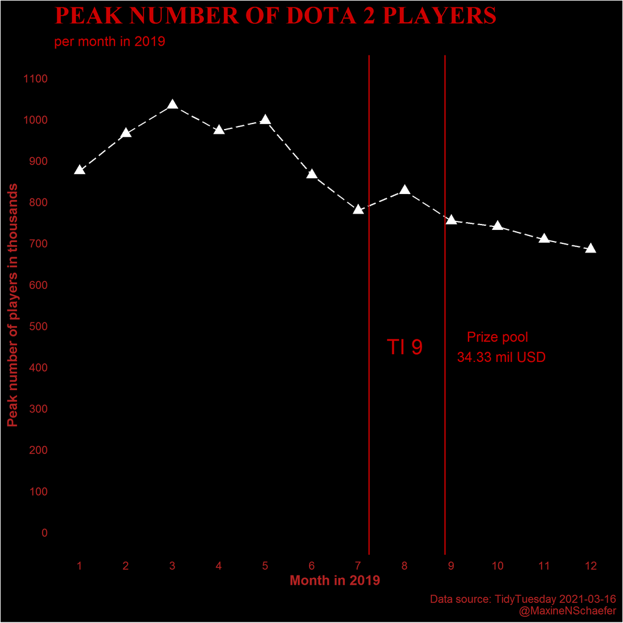

Peak number of players (in thousands) of Dota 2 in 2019

```r
# libraries
library(tidytuesdayR) # only to initially download data
library(tidyverse)
library(ggdark) # for dark minimal theme

# Download and save data
tuesdata <- tidytuesdayR::tt_load('2021-03-16')
dat <- tuesdata$games

# TI start and end
TIstart <- (7/30) + 7
TIend <- (26/30) + 8

# Generate graph

p_final <-

  # get data ready
 dat %>%

  # filter data to include only Dota 2 for 2019
  filter(gamename == "Dota 2", # keep only Dota 2
         year == 2019) %>%     # keep only year 2019

  # make axis more readable
  mutate(peak_in_thousands = round((peak/1000), 0 )) %>% # reduce numbers on the graph by dividing by 1000

  # convert months to numbers so that the months are listed in order in the graph
  mutate(month = case_when(
    month == "January" ~ 1,
    month == "February" ~ 2,
    month == "March" ~ 3,
    month == "April" ~ 4,
    month == "May" ~ 5,
    month == "June" ~ 6,
    month == "July" ~ 7,
    month == "August" ~ 8,
    month == "September" ~ 9,
    month == "October" ~ 10,
    month == "November" ~ 11,
    month == "December" ~ 12
  )) %>% mutate(month = as.numeric(month)) %>%  # convert to numeric so that the months will be listed in order


# base graph
 ggplot(aes(x = month, y = peak_in_thousands)) +
  geom_point(shape = 17, size = 3) + # add points
  geom_line(linetype = 5) + # add lines to join points

  # add labels
  labs(x = "Month in 2019",
       y = "Peak number of players in thousands",
       title = "PEAK NUMBER OF DOTA 2 PLAYERS",
       subtitle = "per month in 2019",
       caption = "Data source: TidyTuesday 2021-03-16
       @MaxineNSchaefer") +

  # fix axis breaks and limits
  scale_x_continuous(n.breaks = 12) + # have a break for each month
  scale_y_continuous(limits = c(0, 1100), breaks = c(0, 100, 200, 300, 400, 500, 600, 700, 800, 900, 1000, 1100)) + # start at 0

  # add start and end dates of The International which I got from https://liquipedia.net/dota2/The_International/2019#Viewership_Stats
  geom_vline(xintercept = TIstart, color = "#cc0000") + # add start date and color using Dota 2 colour
  geom_vline(xintercept = TIend, color = "#cc0000") + # add end date and color using Dota 2 colour

    # add label for TI, and prize pool
  annotate(geom="text", x=8, y=450, label="TI 9", color="#cc0000", size = 6) + # add text to graph
  annotate(geom="text", x=10, y=450, label= # add text to indicate prize pool value
  "Prize pool
  34.33 mil USD", color="#cc0000", size = 4) +

  # edit theme
dark_theme_minimal() + # add basic dark theme from {ggdark}

  # edit theme to match Dota 2 colours more or less
  theme(axis.title = element_text(colour = "#b22222", face = "bold"),
        plot.title = element_text(size = 20, colour = "#cc0000", face = "bold", family = "serif"), #change the font for the title
        plot.subtitle = element_text(colour = "#cc0000"),
        plot.caption = element_text(colour = "#b22222"),
        axis.text = element_text(colour = "#b22222"),
        panel.grid.major = element_blank(), # remove grid lines
        panel.grid.minor = element_blank())  # remove grid lines

p_final
# ggsave("final_plot.png")
```